# abTesting_DC

Christian Julca

## Data

Los datos se consultan de la base de datos recolectados de las personas que dan click en el botón de adoptar de [una página web](https://assets.datacamp.com/production/repositories/2292/datasets/52b52cb1ca28ce10f9a09689325c4d94d889a6da/experiment_data.csv) de adopción de mascotas

| user_id | timestamp | group | landing_page | converted |
| --- | --- | --- | --- | --- |
| 851104 | 2017-01-21 22:11:48.556739 | control | old_page | 0 |
| 804228 | 2017-01-12 08:01:45.159739 | control | old_page | 0 |
| 661590 | 2017-01-11 16:55:06.154213 | treatment | new_page | 0 |
| 853541 | 2017-01-08 18:28:03.143765 | treatment | new_page | 0 |
| 864975 | 2017-01-21 01:52:26.210827 | control | old_page | 1 |
| 936923 | 2017-01-10 15:20:49.083499 | control | old_page | 0 |

## Exploring Data

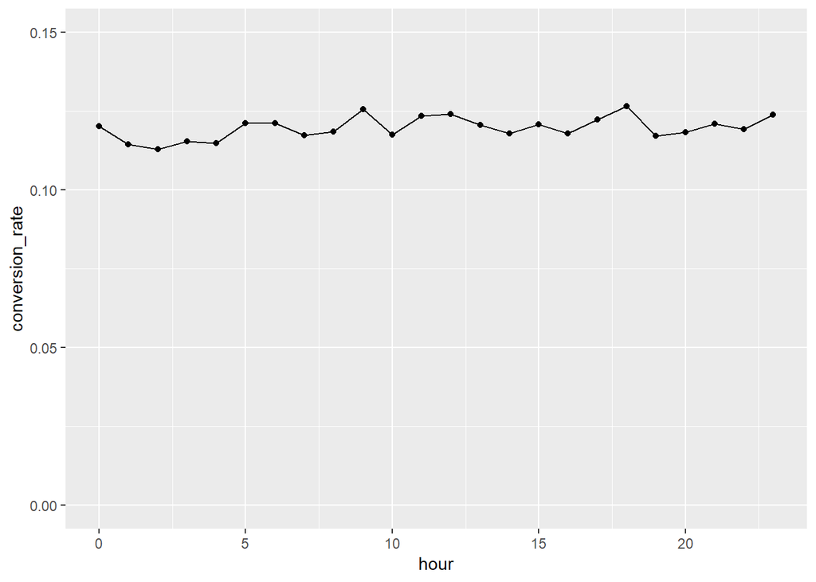

## Power Analysis

El tamaño del experimento es la primera pregunta que debemos hacernos, un tamaño muy pequeño nos puede llevar a un bajo nivel de significancia sobre el efecto esperado. Por otro lado un tamaño muy alto puede elevar nuestros costos de evaluación del tratamiento.

**Power Analysis**, te permite saber cual debería ser el tamaño de la muestra para el experimento. Solo necesita los siguientes insumos:

- **Test Estadístico `SSizeLogisticBin`**: que se planea utilizar.
- **Línea de base `p1`**: valor actual del indicador a evaluar.
- **Valor esperado `p2`**: valor esperado del indicador a evaluar luego del tratamiento.
- **Proporción de datos `B`** para el grupo tratado
- **Alpha/límite de significancia `alpha`**
- **power/1-$\beta$ `power`**: probabilidad de rechazar correctamente la hipótesis nula.

Para aplicar **Power Analysis** en R utilizamos la librería `powerMediation`

```r
library(powerMediation)

total_sample_size <- SSizeLogisticBin(
  p1=0.118,
  p2=0.120,
  B=0.5,
  alpha=0.05,
  power=0.8
  )
total_sample_size
```

```
## [1] 822867
```

## Analyzing Results

```r
df3 <-df %>%
  group_by(group) %>%
  summarize(conversion_rate=mean(converted), N=n())
kable(df3)
```

| group | conversion_rate | N |
| --- | --- | --- |
| control | 0.1203992 | 147202 |
| treatment | 0.1189196 | 147276 |

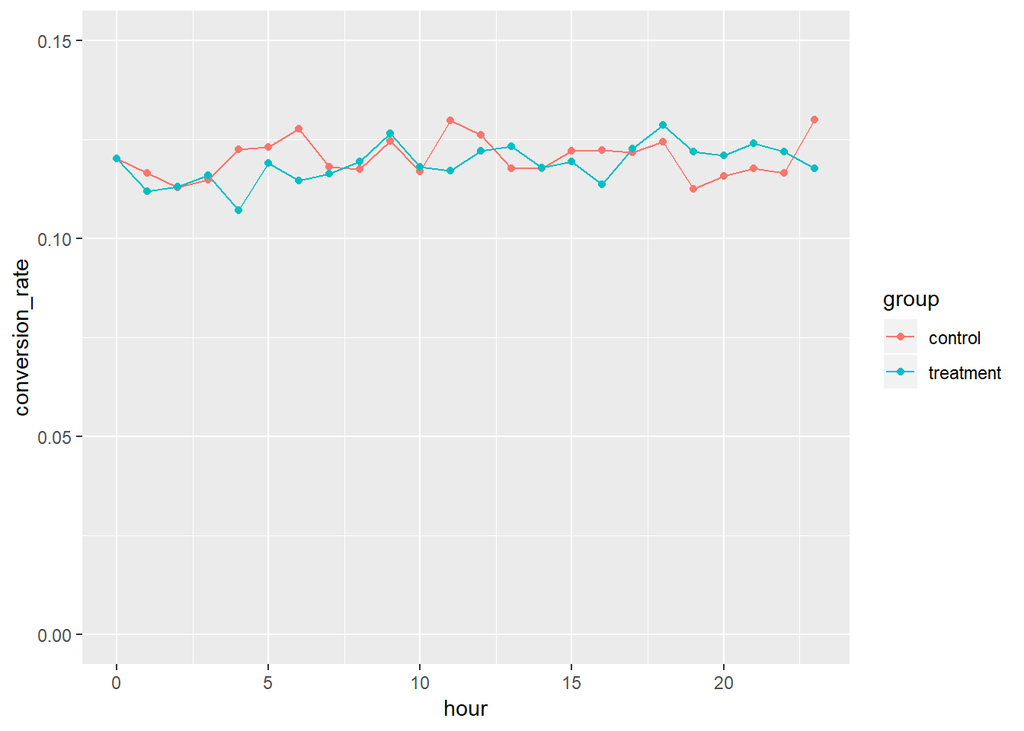